# Implementing a parallel mean filter

(Thanks to Guilherme Ludwig.)

## Mean filters

Images in computers are stored as matrices, usually one for each of three color channels. A mean filter for a window of size $k$ is a transformation of a color channel such that each pixel $x_{i,j}$ is replaced by an average of some nearby values of the same color channel (depending on $k$).

Suppose the window is a square. For $k=1$, the window centered around the $x_{i,j}$-th component of a matrix is

$\begin{pmatrix} x_{i-1,j-1} & x_{i-1,j} & x_{i-1,j+1} \\ x_{i,j-1} & x_{i,j} & x_{i,j+1} \\ x_{i+1,j-1} & x_{i+1,j} & x_{i+1,j+1} \\ \end{pmatrix}$

and the filtered $x^\ast_{i,j}$ is the average of all 9 values. For $k=2$, the window becomes instead

$\begin{pmatrix} x_{i-2,j-2} & x_{i-2,j-1} & x_{i-2,j} & x_{i-2,j+1} & x_{i-2,j+2} \\ x_{i-1,j-2} & x_{i-1,j-1} & x_{i-1,j} & x_{i-1,j+1} & x_{i-1,j+2} \\ x_{i,j-2} & x_{i,j-1} & x_{i,j} & x_{i,j+1} & x_{i,j+2} \\ x_{i+1,j-2} & x_{i+1,j-1} & x_{i+1,j} & x_{i+1,j+1} & x_{i+1,j+2} \\ x_{i+2,j-2} & x_{i+2,j-1} & x_{i+2,j} & x_{i+2,j+1} & x_{i+2,j+2} \\ \end{pmatrix}$

and the filtered $x^\ast_{i,j}$ is the average of all 25 values.

For example, here is a $5 \times 5$ pixels image red channel whose values I made up:

$\begin{pmatrix} 0.5 & 0.5 & 0.4 & 0.4 & 0.3 \\ 0.5 & 0.5 & 0.4 & 0.4 & 0.3 \\ 0.4 & 0.4 & 0.3 & 0.3 & 0.2 \\ 0.4 & 0.3 & 0.2 & 0.2 & 0.2 \\ 0.3 & 0.3 & 0.2 & 0.1 & 0.1 \\ \end{pmatrix}$

For $k = 1$, a filtered version of this matrix replaces $x_{2,2} = 0.5$ with $x^\ast_{2,2} = 0.4333$, $x_{2,3} = 0.4$ with $x^\ast_{2,3} = 0.4$, $x_{3,2} = 0.4$ with $x^\ast_{3,2} = 0.3777$, etc. For the edge values (like $x_{1,1}$), treat the values outside of the matrix as zeros (there are better choices). This is calling “padding” the image with zeros. For example, for $k = 1$ we might enlarge the matrix so that it becomes

$\begin{pmatrix} 0.0 & 0.0 & 0.0 & 0.0 & 0.0 & 0.0 & 0.0 \\ 0.0 & 0.5 & 0.5 & 0.4 & 0.4 & 0.3 & 0.0 \\ 0.0 & 0.5 & 0.5 & 0.4 & 0.4 & 0.3 & 0.0 \\ 0.0 & 0.4 & 0.4 & 0.3 & 0.3 & 0.2 & 0.0 \\ 0.0 & 0.4 & 0.3 & 0.2 & 0.2 & 0.2 & 0.0 \\ 0.0 & 0.3 & 0.3 & 0.2 & 0.1 & 0.1 & 0.0 \\ 0.0 & 0.0 & 0.0 & 0.0 & 0.0 & 0.0 & 0.0 \\ \end{pmatrix}$

and consequently $x^\ast_{1,1} = 0.2222$. To see this in action, let’s implement some code:

```r
# original matrix
X <- matrix(c(.5,.5,.4,.4,.3,.5,.5,.4,.3,.3,.4,.4,.3,.2,.2,.4,.4,.3,.2,.1,.3,.3,.2,.2,.1), ncol=5)
X
```

```
##      [,1] [,2] [,3] [,4] [,5]
## [1,]  0.5  0.5  0.4  0.4  0.3
## [2,]  0.5  0.5  0.4  0.4  0.3
## [3,]  0.4  0.4  0.3  0.3  0.2
## [4,]  0.4  0.3  0.2  0.2  0.2
## [5,]  0.3  0.3  0.2  0.1  0.1
```

```r
k <- 1
pad.X <- matrix(0, dim(X)[1]+2*k, dim(X)[2]+2*k)
pad.X[(k+1):(dim(X)[1]+k), (k+1):(dim(X)[2]+k)] <- X
pad.X
```

```
##      [,1] [,2] [,3] [,4] [,5] [,6] [,7]
## [1,]    0  0.0  0.0  0.0  0.0  0.0    0
## [2,]    0  0.5  0.5  0.4  0.4  0.3    0
## [3,]    0  0.5  0.5  0.4  0.4  0.3    0
## [4,]    0  0.4  0.4  0.3  0.3  0.2    0
## [5,]    0  0.4  0.3  0.2  0.2  0.2    0
## [6,]    0  0.3  0.3  0.2  0.1  0.1    0
## [7,]    0  0.0  0.0  0.0  0.0  0.0    0
```

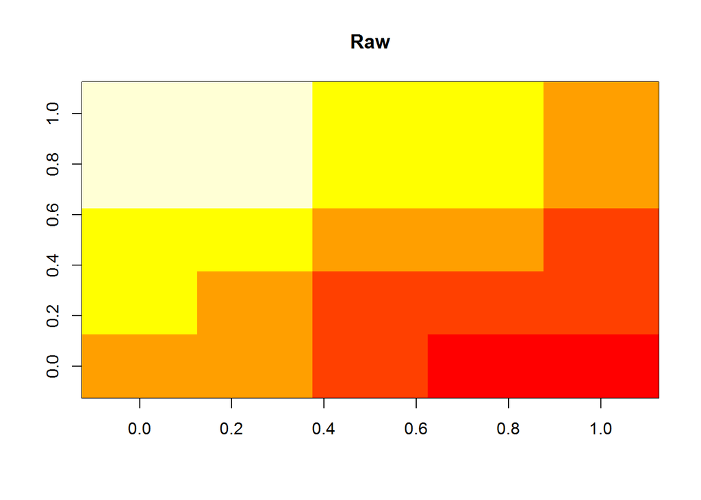

```r
image(t(X[nrow(X):1,]), main="Raw") # image() needs to rotate and flip matrices for display
```

After padding, take the averages around each non-pad entry, and crop the padding out (code hidden):

```
##           [,1]      [,2]      [,3]      [,4]       [,5]
## [1,] 0.2222222 0.3111111 0.2888889 0.2444444 0.15555556
## [2,] 0.3111111 0.4333333 0.4000000 0.3333333 0.21111111
## [3,] 0.2777778 0.3777778 0.3333333 0.2777778 0.17777778
## [4,] 0.2333333 0.3111111 0.2555556 0.2000000 0.12222222
## [5,] 0.1444444 0.1888889 0.1444444 0.1111111 0.06666667
```

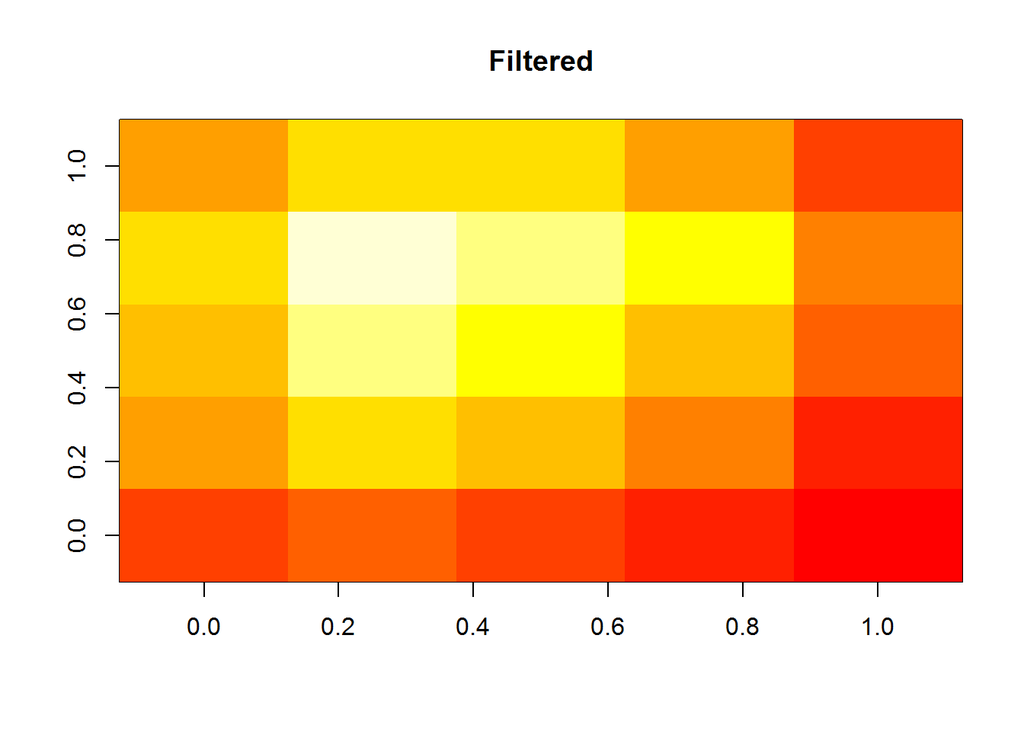

## Creating a test case

Save the file Van_Gogh.png (“Wheatfield with Crows”) in the same directory as your script. (Run “Session” -> “Set Working Directory” if necessary; do not change the file name. The `readPNG()` function we’ll use does not take hyperlink connections.) Here is the image:

[figure not shown]

Now we’ll read the image into R and decompose it into three color channels:

```r
if (!require("png")) {
  install.packages("png")
  stopifnot(require("png"))
  }
str(vg <- readPNG("Van_Gogh.png"))
```

```
##  num [1:374, 1:800, 1:3] 0.1255 0.3647 0.3059 0.1098 0.0235 ...
```

```r
dim(vg)
```

```
## [1] 374 800   3
```

```r
red.vg <- vg[,,1]
green.vg <- vg[,,2]
blue.vg <- vg[,,3]
str(blue.vg)
```

```
##  num [1:374, 1:800] 0.1255 0.2588 0.3373 0.2078 0.0235 ...
```

The `readPNG()` function returns an array, a generalization of a matrix to more than 2 dimensions. Here the third dimension holds the color channels, 1=“Red”, 2=“Green”, and 3=“Blue”, respectively. Taking all rows and all columns, with a fixed third index, gives a matrix; for example, `blue.vg` is a matrix. The data need to be transposed and flipped horizontally to be displayed correctly, but that’s not necessary for your calculations (see `?image`). Here are the channels individually:

[figure not shown]

```r
layout(matrix(1:3, ncol=3))
image(t(red.vg[nrow(red.vg):1,]), col = gray((1:12)/13), main="Red channel")
image(t(green.vg[nrow(green.vg):1,]), col = gray((1:12)/13), main="Green channel")
image(t(blue.vg[nrow(blue.vg):1,]), col = gray((1:12)/13), main="Blue channel")
```

## Implementation

We will run the three channel filtering in parallel. Here are the steps:

- Create a function taking a matrix argument and a $k$ argument.
  - Store the dimensions of the matrix, say, $n \times m$.
  - Pad the image with zeros, depending on $k$. This will make calculations easier. Your matrix is now $(n + 2k) \times (m + 2k)$
  - From $k+1$ to $n+k$ and from $k+1$ to $m+k$ (that is, in the data, but not in the padding), move your window around, taking averages.
  - Crop the padding, so that the filtered matrix is now $n \times m$ again. Return this filtered matrix.
- For each color channel of the image, call the function you implemented in the first bullet. Do this in parallel, using 3 cores.
- Assemble the three processed matrices into an `array` by using the `array()` function. This array must have dimensions $n \times m \times 3$.
- Use `writePNG()` function to create `USERNAME_k.png`, where `k` is the window size.
- Create files `USERNAME_1.png`, `USERNAME_3.png` and `USERNAME_5.png`, using the respective values for `k`.